# Semestral project for MFF UK - Marketing

```python
import matplotlib.pyplot as plt
import seaborn as sns
import numpy as np
import pandas as pd
import sklearn
from sklearn.cluster import KMeans
from sklearn.decomposition import PCA
from scipy.cluster.hierarchy import dendrogram,linkage,fcluster

from sklearn.compose import ColumnTransformer
from sklearn.base import BaseEstimator,TransformerMixin
from sklearn.pipeline import Pipeline,make_pipeline
from sklearn.impute import SimpleImputer
from sklearn.preprocessing import StandardScaler, MinMaxScaler,OneHotEncoder

from sklearn.model_selection import cross_val_score,train_test_split
from sklearn.model_selection import GridSearchCV
from sklearn.metrics import accuracy_score, log_loss

from sklearn.linear_model import LinearRegression,LogisticRegression,Ridge
from sklearn.tree import DecisionTreeClassifier,export_text, DecisionTreeRegressor

from sklearn.neighbors import KNeighborsClassifier
from sklearn.ensemble import RandomForestClassifier, AdaBoostClassifier,BaggingClassifier

from mlxtend.plotting import plot_decision_regions

from IPython.display import display, HTML
```

***The dataset we will be working with can be found at:*** [Kaggle](https://www.kaggle.com/datasets/imakash3011/customer-personality-analysis)

*Github of the project is currently private, but will be published once it is finished*

### About the dataset

It is concerned with the results of a broad marketing campaign across more than 2000 participants. The dataset includes some metadata about the respondents familial background - such as Income, Marital status, or whether there are teenagers living in the household - and details about the purchased data - whether the products were bought as a part of a deal, their quantities, and others. We will be analysing this dataset in a comprehensive manner, examining different quantities, looking for correlations, identifying different groups of citizens that are more prone to certain products, and more.

Now, let us finally open our data:

```python
campaign = pd.read_csv('data/marketing_campaign.csv', sep='\t')
campaign.fillna(campaign.median(numeric_only=True).round(0), inplace=True)
campaign.head(10)
```

|  | ID | Year_Birth | Education | Marital_Status | Income | Kidhome | Teenhome | Dt_Customer | Recency | MntWines | ... | NumWebVisitsMonth | AcceptedCmp3 | AcceptedCmp4 | AcceptedCmp5 | AcceptedCmp1 | AcceptedCmp2 | Complain | Z_CostContact | Z_Revenue | Response |
| --- | --- | --- | --- | --- | --- | --- | --- | --- | --- | --- | --- | --- | --- | --- | --- | --- | --- | --- | --- | --- | --- |
| 0 | 5524 | 1957 | Graduation | Single | 58138.0 | 0 | 0 | 04-09-2012 | 58 | 635 | ... | 7 | 0 | 0 | 0 | 0 | 0 | 0 | 3 | 11 | 1 |
| 1 | 2174 | 1954 | Graduation | Single | 46344.0 | 1 | 1 | 08-03-2014 | 38 | 11 | ... | 5 | 0 | 0 | 0 | 0 | 0 | 0 | 3 | 11 | 0 |
| 2 | 4141 | 1965 | Graduation | Together | 71613.0 | 0 | 0 | 21-08-2013 | 26 | 426 | ... | 4 | 0 | 0 | 0 | 0 | 0 | 0 | 3 | 11 | 0 |
| 3 | 6182 | 1984 | Graduation | Together | 26646.0 | 1 | 0 | 10-02-2014 | 26 | 11 | ... | 6 | 0 | 0 | 0 | 0 | 0 | 0 | 3 | 11 | 0 |
| 4 | 5324 | 1981 | PhD | Married | 58293.0 | 1 | 0 | 19-01-2014 | 94 | 173 | ... | 5 | 0 | 0 | 0 | 0 | 0 | 0 | 3 | 11 | 0 |
| 5 | 7446 | 1967 | Master | Together | 62513.0 | 0 | 1 | 09-09-2013 | 16 | 520 | ... | 6 | 0 | 0 | 0 | 0 | 0 | 0 | 3 | 11 | 0 |
| 6 | 965 | 1971 | Graduation | Divorced | 55635.0 | 0 | 1 | 13-11-2012 | 34 | 235 | ... | 6 | 0 | 0 | 0 | 0 | 0 | 0 | 3 | 11 | 0 |
| 7 | 6177 | 1985 | PhD | Married | 33454.0 | 1 | 0 | 08-05-2013 | 32 | 76 | ... | 8 | 0 | 0 | 0 | 0 | 0 | 0 | 3 | 11 | 0 |
| 8 | 4855 | 1974 | PhD | Together | 30351.0 | 1 | 0 | 06-06-2013 | 19 | 14 | ... | 9 | 0 | 0 | 0 | 0 | 0 | 0 | 3 | 11 | 1 |
| 9 | 5899 | 1950 | PhD | Together | 5648.0 | 1 | 1 | 13-03-2014 | 68 | 28 | ... | 20 | 1 | 0 | 0 | 0 | 0 | 0 | 3 | 11 | 0 |

10 rows × 29 columns

Now that our data is loaded, let us see gow many respondents there actually are, as well as examine the distributions of education, of marital status, and of kid amounts, to get a rough idea with what groups of people we are dealing with.

```
There are 2240 entries and 29 columns
```

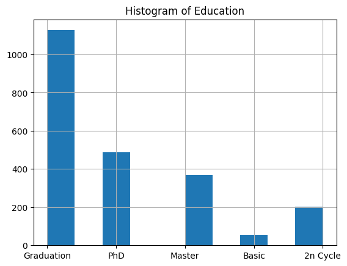

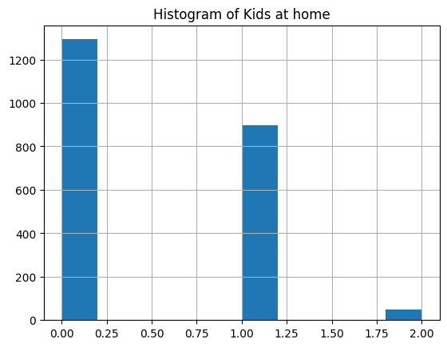

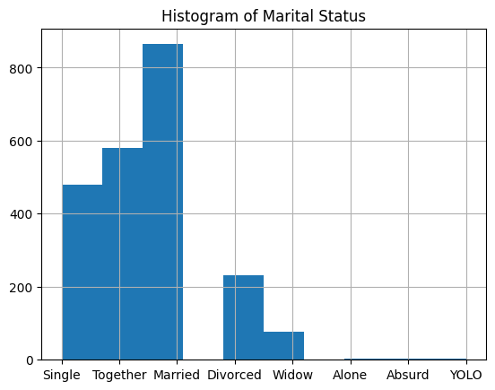

```python
print('There are {} entries and {} columns'.format(campaign.shape[0], campaign.shape[1]))
ed_hist = campaign['Education'].hist()
plt.title('Histogram of Education')
plt.show()

kids_hist = campaign['Kidhome'].hist()
plt.title('Histogram of Kids at home')
plt.show()

ed_hist = campaign['Marital_Status'].hist()
plt.title('Histogram of Marital Status')
plt.show()
```

And manually for income:

```python
np.max(campaign['Income'])
```

```
666666.0
```

```
(array([1678,  554,    7,    0,    0,    0,    0,    0,    0,    1],
      dtype=int64), array([  1730. ,  68223.6, 134717.2, 201210.8, 267704.4, 334198. ,
       400691.6, 467185.2, 533678.8, 600172.4, 666666. ]))
```

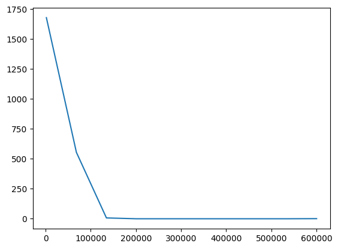

```python
bins = [10**i for i in range(1,5)]
inc_hist = np.histogram(campaign['Income'])
print(inc_hist)

plt.plot(inc_hist[1][:-1], inc_hist[0])
plt.show()
```

As expected, Income follows the famous Pareto distribution, having a handful of disproportianetly high-earners with the majority at the bottom.

*Note that we attempted to plot the bar of this income distribution, but the bar did not show.*

Let us now compare the amount of teenagers versus kids our respondents are responsible for.

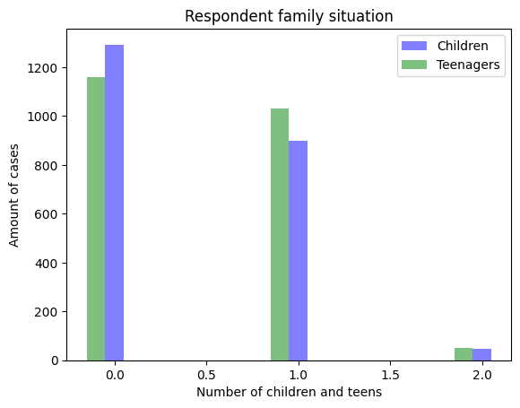

```python
kid_values= list(set(campaign['Kidhome']))
kid_values.sort()
bb=[0]+[i+0.1 for i in kid_values]
plt.bar(kid_values, np.histogram(campaign['Kidhome'], bins=bb)[0], width=0.1, alpha=0.5, color='blue', label='Children')
plt.bar([(i-0.1) for i in kid_values], np.histogram(campaign['Teenhome'], bins=bb)[0], width=0.1, alpha=0.5, color='green', label='Teenagers')
plt.xlabel('Number of children and teens')
plt.ylabel('Amount of cases')
plt.legend()
plt.title('Respondent family situation')
```

[figure not shown]

```python
def ukaz(ax,data,text, color):
    plt.title(text)
    inc_hist = np.histogram(data['Income'])

    plt.plot(inc_hist[1][:-1], inc_hist[0], color, label=text)
    plt.legend()
    plt.ylabel('Amounts of people')

no_kid = campaign['Kidhome'] == 0
one_kid = campaign['Kidhome'] == 1
two_kid = campaign['Kidhome'] == 2

fig, ax_lst = plt.subplots(3, 1, figsize=(6, 6))  # 3 rows, 1 column; numbered row-wise
fig.subplots_adjust(hspace=0.4, wspace=0.4)
fig.suptitle('Income distributions')  # Add a title so we know which it is
sub1=plt.subplot(311)
ukaz(plt, campaign[no_kid],'No children at home','-b')
ax2=plt.subplot(312)
ukaz(plt, campaign[one_kid],'One child at home','>-.g')
plt.subplot(313)
ukaz(plt, campaign[two_kid],'Two children at home','p:m')
plt.xlabel('Income')
plt.show()
```

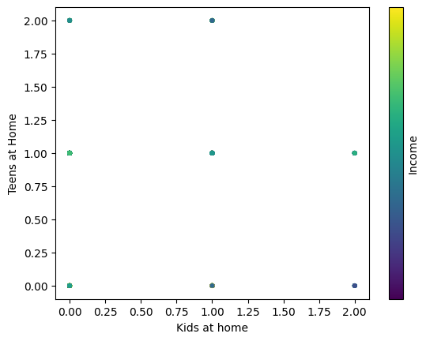

```python
plt.scatter(campaign['Kidhome'], campaign['Teenhome'], c=campaign['Income'], s=np.log(campaign['Income']))
plt.xlabel('Kids at home')
plt.ylabel('Teens at Home')
cbar=plt.colorbar(ticks=range(6))
plt.clim(1000, 100000)
cbar.set_label('Income', rotation=90)
plt.show()
```

This plot perhaps wasn't the best of plots, but it was certainly informative :D

We unfortunately don't have the kind of data that would fit our scatterplot well, so we will settle for this. Let's now take a look at marital status instead.

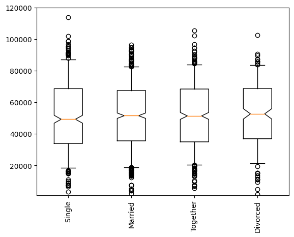

```python
single = campaign['Marital_Status'] == 'Single'
married = campaign['Marital_Status'] == 'Married'
together = campaign['Marital_Status'] == 'Together'
divorced = campaign['Marital_Status'] == 'Divorced'

nic=plt.boxplot(np.array([campaign[single].Income, campaign[married].Income, campaign[together].Income, campaign[divorced].Income],dtype=object),
                notch=True,
                whis=(5, 95))
plt.xticks([ 1, 2, 3, 4], ['Single','Married','Together', 'Divorced'],rotation=90)
plt.ylim([1000, 120000])
plt.grid(False)
plt.show()
```

Let us now examine some numbers of bought items for a change. Meaning number of items bought via the web, number of items bought via a catalogue, and number of items bought via Stores.

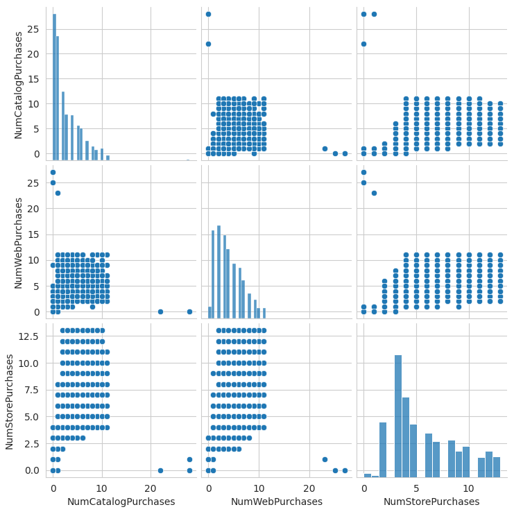

```python
with sns.axes_style(style='whitegrid'):#{darkgrid, whitegrid, dark, white, ticks}
    sns.pairplot(campaign[['NumCatalogPurchases','NumWebPurchases','NumStorePurchases']], height=2.5)
plt.show()
```

## Lab 3 iteration

*This lab focused on data aggregation by features and operation broadcasting.*

Let's start by taking a look at some of our product purchases aggregates, starting with number of complaints recieved.

```python
print('We recieved a total of {} complaints from customers.'.format(campaign.Complain.sum()))
```

```
We recieved a total of 21 complaints from customers.
```

Let us now examine if the respondents marital status had any impact on their willingness to complain:

```python
campaign.groupby('Marital_Status')['Complain'].sum()
```

```
Marital_Status
Absurd      0
Alone       0
Divorced    2
Married     8
Single      6
Together    5
Widow       0
YOLO        0
Name: Complain, dtype: int64
```

This might seem like marriage indeed makes people more irritable, but let us not forget - there are notably more married respondents than any other group in our dataset.

```python
campaign.groupby('Marital_Status')['Complain'].mean()
```

```
Marital_Status
Absurd      0.000000
Alone       0.000000
Divorced    0.008621
Married     0.009259
Single      0.012500
Together    0.008621
Widow       0.000000
YOLO        0.000000
Name: Complain, dtype: float64
```

So in reality, it is being single that's most correlated with a bad mood ;)

Let us instead see how many web purchases one is likely to make based on his marital status.

```python
campaign.groupby('Marital_Status')['NumWebPurchases'].aggregate(['mean', 'median', 'sum'])
```

| Marital_Status | mean | median | sum |
| --- | --- | --- | --- |
| Absurd | 3.500000 | 3.5 | 7 |
| Alone | 5.000000 | 3.0 | 15 |
| Divorced | 4.310345 | 4.0 | 1000 |
| Married | 4.087963 | 4.0 | 3532 |
| Single | 3.872917 | 3.0 | 1859 |
| Together | 4.081034 | 4.0 | 2367 |
| Widow | 4.623377 | 4.0 | 356 |
| YOLO | 7.000000 | 7.0 | 14 |

This is rather surprising, as one would expect Singles, who are no doubt younger on average, to take the lead in this category.

Let us now get an overview of what kind of purchases what groups are more likely to make.

```python
campaign.groupby('Marital_Status')[['NumDealsPurchases', 'NumWebPurchases', 'NumCatalogPurchases', 'NumStorePurchases', 'NumWebVisitsMonth']].aggregate(['mean', 'median', 'sum', 'count'])
```

| Marital_Status | NumDealsPurchases mean | NumDealsPurchases median | NumDealsPurchases sum | NumDealsPurchases count | NumWebPurchases mean | NumWebPurchases median | NumWebPurchases sum | NumWebPurchases count | NumCatalogPurchases mean | NumCatalogPurchases median | NumCatalogPurchases sum | NumCatalogPurchases count | NumStorePurchases mean | NumStorePurchases median | NumStorePurchases sum | NumStorePurchases count | NumWebVisitsMonth mean | NumWebVisitsMonth median | NumWebVisitsMonth sum | NumWebVisitsMonth count |
| --- | --- | --- | --- | --- | --- | --- | --- | --- | --- | --- | --- | --- | --- | --- | --- | --- | --- | --- | --- | --- |
| Absurd | 2.000000 | 2.0 | 4 | 2 | 3.500000 | 3.5 | 7 | 2 | 7.500000 | 7.5 | 15 | 2 | 6.500000 | 6.5 | 13 | 2 | 1.500000 | 1.5 | 3 | 2 |
| Alone | 3.666667 | 4.0 | 11 | 3 | 5.000000 | 3.0 | 15 | 3 | 0.666667 | 1.0 | 2 | 3 | 4.000000 | 4.0 | 12 | 3 | 6.333333 | 6.0 | 19 | 3 |
| Divorced | 2.435345 | 2.0 | 565 | 232 | 4.310345 | 4.0 | 1000 | 232 | 2.672414 | 2.0 | 620 | 232 | 5.818966 | 5.0 | 1350 | 232 | 5.487069 | 6.0 | 1273 | 232 |
| Married | 2.392361 | 2.0 | 2067 | 864 | 4.087963 | 4.0 | 3532 | 864 | 2.625000 | 2.0 | 2268 | 864 | 5.850694 | 5.0 | 5055 | 864 | 5.364583 | 6.0 | 4635 | 864 |
| Single | 2.131250 | 1.0 | 1023 | 480 | 3.872917 | 3.0 | 1859 | 480 | 2.600000 | 2.0 | 1248 | 480 | 5.639583 | 4.0 | 2707 | 480 | 5.283333 | 6.0 | 2536 | 480 |
| Together | 2.324138 | 2.0 | 1348 | 580 | 4.081034 | 4.0 | 2367 | 580 | 2.675862 | 2.0 | 1552 | 580 | 5.736207 | 5.0 | 3327 | 580 | 5.260345 | 5.5 | 3051 | 580 |
| Widow | 2.337662 | 2.0 | 180 | 77 | 4.623377 | 4.0 | 356 | 77 | 3.324675 | 3.0 | 256 | 77 | 6.415584 | 6.0 | 494 | 77 | 4.883117 | 5.0 | 376 | 77 |
| YOLO | 5.000000 | 5.0 | 10 | 2 | 7.000000 | 7.0 | 14 | 2 | 1.000000 | 1.0 | 2 | 2 | 6.000000 | 6.0 | 12 | 2 | 8.000000 | 8.0 | 16 | 2 |

```python
campaign.groupby('Education')[['NumDealsPurchases', 'NumWebPurchases', 'NumCatalogPurchases', 'NumStorePurchases', 'NumWebVisitsMonth']].aggregate(['mean', 'median', 'sum', 'count'])
```

| Education | NumDealsPurchases mean | NumDealsPurchases median | NumDealsPurchases sum | NumDealsPurchases count | NumWebPurchases mean | NumWebPurchases median | NumWebPurchases sum | NumWebPurchases count | NumCatalogPurchases mean | NumCatalogPurchases median | NumCatalogPurchases sum | NumCatalogPurchases count | NumStorePurchases mean | NumStorePurchases median | NumStorePurchases sum | NumStorePurchases count | NumWebVisitsMonth mean | NumWebVisitsMonth median | NumWebVisitsMonth sum | NumWebVisitsMonth count |
| --- | --- | --- | --- | --- | --- | --- | --- | --- | --- | --- | --- | --- | --- | --- | --- | --- | --- | --- | --- | --- |
| 2n Cycle | 2.246305 | 2.0 | 456 | 203 | 3.729064 | 3.0 | 757 | 203 | 2.320197 | 1.0 | 471 | 203 | 5.507389 | 4.0 | 1118 | 203 | 5.453202 | 6.0 | 1107 | 203 |
| Basic | 1.796296 | 1.0 | 97 | 54 | 1.888889 | 2.0 | 102 | 54 | 0.481481 | 0.0 | 26 | 54 | 2.851852 | 3.0 | 154 | 54 | 6.870370 | 7.0 | 371 | 54 |
| Graduation | 2.309672 | 2.0 | 2603 | 1127 | 4.125111 | 4.0 | 4649 | 1127 | 2.725821 | 2.0 | 3072 | 1127 | 5.829636 | 5.0 | 6570 | 1127 | 5.287489 | 6.0 | 5959 | 1127 |
| Master | 2.427027 | 2.0 | 898 | 370 | 4.032432 | 3.0 | 1492 | 370 | 2.570270 | 2.0 | 951 | 370 | 5.897297 | 5.0 | 2182 | 370 | 5.178378 | 6.0 | 1916 | 370 |
| PhD | 2.374486 | 2.0 | 1154 | 486 | 4.423868 | 4.0 | 2150 | 486 | 2.969136 | 2.0 | 1443 | 486 | 6.061728 | 5.0 | 2946 | 486 | 5.259259 | 5.0 | 2556 | 486 |

```python
campaign.groupby('Education')[['Income']].aggregate(['mean', 'median', 'sum', 'count'])
```

| Education | Income mean | Income median | Income sum | Income count |
| --- | --- | --- | --- | --- |
| 2n Cycle | 47688.591133 | 46891.0 | 9680784.0 | 203 |
| Basic | 20306.259259 | 20744.0 | 1096538.0 | 54 |
| Graduation | 52707.310559 | 51651.0 | 59401139.0 | 1127 |
| Master | 52896.783784 | 51044.5 | 19571810.0 | 370 |
| PhD | 56096.308642 | 55005.0 | 27262806.0 | 486 |

Go to school kids.

Now let's do one more complex query

```
         total_spending
Recency
0                 12601
1                 15864
2                 17330
3                 18486
4                 17953
```

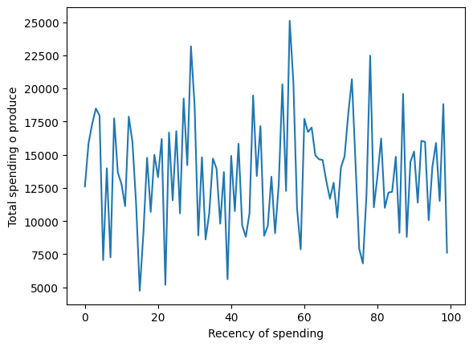

```python
def f(x):
    d = {}
    d['total_spending'] = (x['MntFruits'] + x['MntWines'] + x['MntMeatProducts'] + x['MntFishProducts'] + x['MntSweetProducts'] + x['MntGoldProds']).sum()
    return pd.Series(d)

aggregated = campaign.groupby(['Recency']).apply(f)
print(aggregated.head(5))
plt.plot(aggregated)
plt.ylabel("Total spending o produce")
plt.xlabel("Recency of spending")
plt.show()
```

And it is plain to see that total spending doesn't follow a particularly obvious function, though it may yet turn out that individual produces follow seasonal patterns.

## Lab 5 iteration

*This lab focused on k-means clustering.*

```python
amounts_spent = campaign.groupby('ID')[['MntFruits', 'MntWines', 'MntMeatProducts', 'MntFishProducts', 'MntSweetProducts', 'MntGoldProds']]
amounts_sum = amounts_spent.sum()
df_sums = pd.DataFrame(amounts_sum.sum(axis=1))
df_sums
spent_proportions = amounts_sum.div(df_sums.values)

MEANS = 6
```

We acquire the proportions of different kinds of purchases.

```python
kmeans = KMeans(n_clusters=MEANS, n_init='auto')
kmeans.fit(spent_proportions)
y_kmeans = kmeans.predict(spent_proportions)
```

```python
fruits_idx=np.where(spent_proportions.columns=='MntFruits')[0][0]
wines_idx=np.where(spent_proportions.columns=='MntWines')[0][0]
meat_idx=np.where(spent_proportions.columns=='MntMeatProducts')[0][0]
```

We pick fruits, wines, and meats to examine for no reason in particular.

```
(-0.01, 0.3)
```

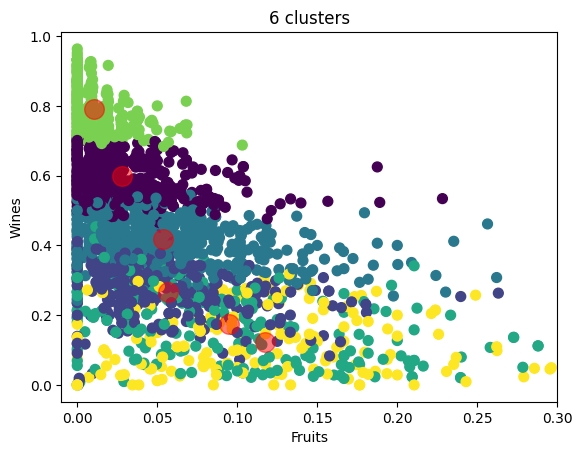

```python
plt.scatter(spent_proportions.MntFruits, spent_proportions.MntWines,
            c=y_kmeans, s=50, cmap='viridis')
plt.xlabel('Fruits')
plt.ylabel('Wines')
plt.title('{} clusters'.format(MEANS))

centers = kmeans.cluster_centers_
plt.scatter(centers[:,fruits_idx], centers[:,wines_idx], c='red', s=200, alpha=0.5)
plt.xlim(-0.01,0.3)
```

This scatterplot does show some promise in our k-means model. While it doesn't separate the amounts of bought fruits particularly well, it does separate several groups of wine spending proportions very well.

```python
n_components=2

pca = PCA(n_components=n_components)
pca.fit(spent_proportions)
```

```
PCA(n_components=2)
```

```python
for i in range(n_components):
    print(spent_proportions.columns[list(pca.components_[i]).index(max(abs(pca.components_[i])))])
```

```
MntWines
MntMeatProducts
```

Performing PCA reveals that amounts of wines and amounts of bought meat are the better attributes by which to re-express our data. This is reinforced by the means our k-means algorithm found. Do note that there are 3 wine clusters and no fruit clusters.

```python
for i in np.arange(MEANS):
    print(spent_proportions.columns[list(centers[i]).index(max(abs(centers[i])))])
```

```
MntWines
MntMeatProducts
MntWines
MntGoldProds
MntWines
MntFishProducts
```

Seems nothing sells quite like alcohol

```python
X_pca = pca.transform(spent_proportions)
centers_pca = pca.transform(centers)
```

We re-express the data using PCA into a two-feature dataset (We can do more, but that wouldn't look as pretty in graphs), in order to find best clusters possible.

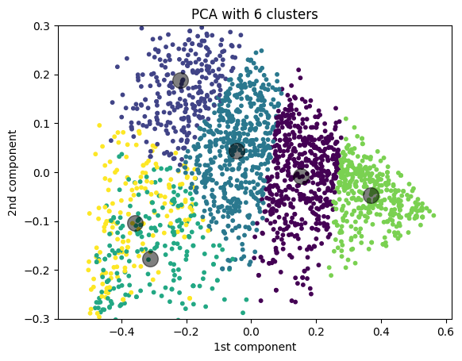

```python
plt.scatter(X_pca[:, 0], X_pca[:, 1], c=y_kmeans, s=10, cmap='viridis')
plt.xlabel('1st component')
plt.ylabel('2nd component')
plt.title('PCA with {} clusters'.format(MEANS))

plt.scatter(centers_pca[:, 0], centers_pca[:, 1], c='black', s=200, alpha=0.5)
plt.ylim(-0.3,0.3)
plt.show()
```

Indeed, clustering our new data seems to give us significantly more information, seeing as only two of the clusters have significant overlap. Using 5 clusters would no doubt be better.

```python
MEANS = 4
kmeans = KMeans(n_clusters=MEANS, n_init='auto')
kmeans.fit(spent_proportions, y=campaign['Income'])
y_kmeans = kmeans.predict(spent_proportions)
y_kmeans
```

```
array([0, 1, 2, ..., 3, 3, 0])
```

Out of curiosity, we now attempt to predict incomes based on purchase proportionalities.

```python
np.histogram(y_kmeans,bins=(MEANS))
```

```
(array([525, 608, 732, 375], dtype=int64),
 array([0.  , 0.75, 1.5 , 2.25, 3.  ]))
```

```
(-0.01, 0.3)
```

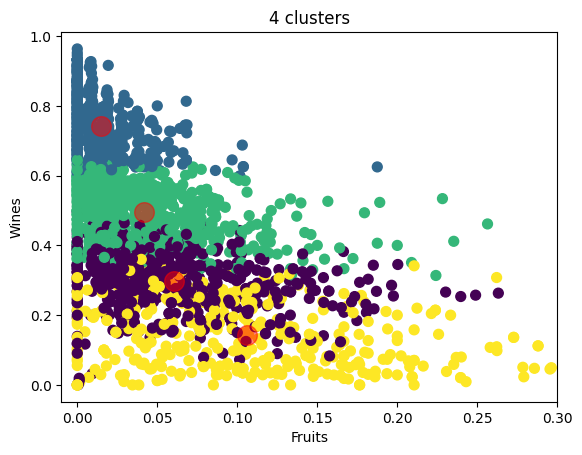

```python
plt.scatter(spent_proportions.MntFruits, spent_proportions.MntWines,
            c=y_kmeans, s=50, cmap='viridis')
plt.xlabel('Fruits')
plt.ylabel('Wines')
plt.title('{} clusters'.format(MEANS))

centers = kmeans.cluster_centers_
plt.scatter(centers[:,fruits_idx], centers[:,wines_idx], c='red', s=200, alpha=0.5)
plt.xlim(-0.01,0.3)
```

```python
X_pca = pca.transform(spent_proportions)
centers_pca = pca.transform(centers)
```

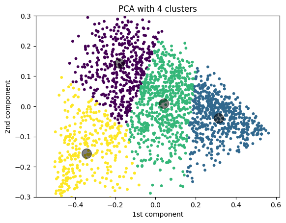

```python
plt.scatter(X_pca[:, 0], X_pca[:, 1], c=y_kmeans, s=10, cmap='viridis')
plt.xlabel('1st component')
plt.ylabel('2nd component')
plt.title('PCA with {} clusters'.format(MEANS))

plt.scatter(centers_pca[:, 0], centers_pca[:, 1], c='black', s=200, alpha=0.5)
plt.ylim(-0.3,0.3)
plt.show()
```

```python
for i in np.arange(MEANS):
    print(spent_proportions.columns[list(centers[i]).index(max(abs(centers[i])))])
```

```
MntMeatProducts
MntWines
MntWines
MntGoldProds
```

```python
one_cluster = campaign[y_kmeans == 0]['Income']
print('One of our {} clusters predicts a range of incomes from {} to {}, not making proportions of purchased goods a very good predictor'.format(MEANS, np.min(one_cluster), np.max(one_cluster)))
```

```
One of our 4 clusters predicts a range of incomes from 1730.0 to 153924.0, not making proportions of purchased goods a very good predictor
```

How about we try to predict by straight up amounts of purchased goods then?

```python
MEANS = 4
amounts_spent = campaign[['MntFruits', 'MntWines', 'MntMeatProducts', 'MntFishProducts', 'MntSweetProducts', 'MntGoldProds']]
kmeans = KMeans(n_clusters=MEANS, n_init='auto')
kmeans.fit(amounts_spent.values, y=campaign['Income'])
y_kmeans = kmeans.predict(amounts_spent)
y_kmeans
```

```
array([2, 0, 3, ..., 1, 3, 0])
```

```python
fruits_idx=np.where(amounts_spent.columns=='MntFruits')[0][0]
wines_idx=np.where(amounts_spent.columns=='MntWines')[0][0]
meat_idx=np.where(amounts_spent.columns=='MntMeatProducts')[0][0]
```

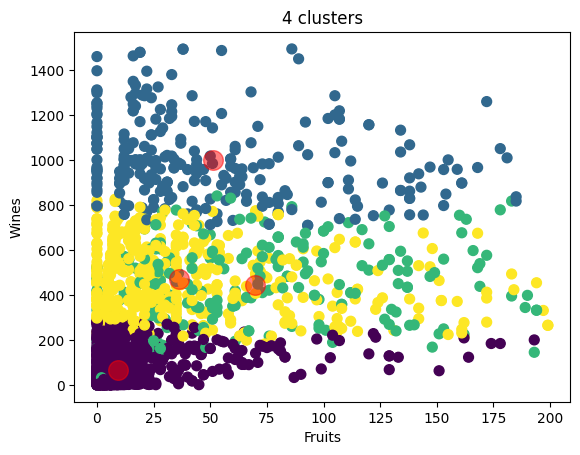

```python
plt.scatter(amounts_spent.MntFruits, amounts_spent.MntWines,
            c=y_kmeans, s=50, cmap='viridis')
plt.xlabel('Fruits')
plt.ylabel('Wines')
plt.title('{} clusters'.format(MEANS))

centers = kmeans.cluster_centers_
plt.scatter(centers[:,fruits_idx], centers[:,wines_idx], c='red', s=200, alpha=0.5)
```

```python
n_components=2

pca = PCA(n_components=n_components)
pca.fit(amounts_spent)
```

```
PCA(n_components=2)
```

```python
for i in range(n_components):
    print(amounts_spent.columns[list(pca.components_[i]).index(max(abs(pca.components_[i])))])
```

```
MntWines
MntMeatProducts
```

```python
X_pca = pca.transform(amounts_spent)
centers_pca = pca.transform(centers)
```

[figure not shown]

```python
plt.scatter(X_pca[:, 0], X_pca[:, 1], c=y_kmeans, s=10, cmap='viridis')
plt.xlabel('1st component')
plt.ylabel('2nd component')
plt.title('PCA with {} clusters'.format(MEANS))

plt.scatter(centers_pca[:, 0], centers_pca[:, 1], c='black', s=200, alpha=0.5)
plt.ylim(-0.3,0.3)
plt.show()
```

```python
one_cluster = campaign[y_kmeans == 0]['Income']
print('One of our {} clusters predicts a range of incomes from {} to {}, not making amounts of purchased goods a very good predictor either'.format(MEANS, np.min(one_cluster), np.max(one_cluster)))
```

```
One of our 4 clusters predicts a range of incomes from 1730.0 to 666666.0, not making amounts of purchased goods a very good predictor either
```

## Lab 6 iteration

This lab focused on predictions using different ML approaches

Our main focus is going to be on predicting what products are purchased by a consumer based on his socioeconomic background.

```python
fish_targets = campaign['MntFishProducts']
wine_targets = campaign['MntWines']
train_data = campaign[['Income', 'Marital_Status', 'Education', 'Kidhome', 'Teenhome', 'Year_Birth']]
hot_enc = OneHotEncoder(handle_unknown="ignore")
train_data = train_data.join(pd.DataFrame(hot_enc.fit_transform(train_data[['Marital_Status', 'Education']]).toarray()))
train_data.drop('Marital_Status', axis=1, inplace=True)
train_data.drop('Education', axis=1, inplace=True)
train_data.columns = train_data.columns.astype(str)
train_data
```

|  | Income | Kidhome | Teenhome | Year_Birth | 0 | 1 | 2 | 3 | 4 | 5 | 6 | 7 | 8 | 9 | 10 | 11 | 12 |
| --- | --- | --- | --- | --- | --- | --- | --- | --- | --- | --- | --- | --- | --- | --- | --- | --- | --- |
| 0 | 58138.0 | 0 | 0 | 1957 | 0.0 | 0.0 | 0.0 | 0.0 | 1.0 | 0.0 | 0.0 | 0.0 | 0.0 | 0.0 | 1.0 | 0.0 | 0.0 |
| 1 | 46344.0 | 1 | 1 | 1954 | 0.0 | 0.0 | 0.0 | 0.0 | 1.0 | 0.0 | 0.0 | 0.0 | 0.0 | 0.0 | 1.0 | 0.0 | 0.0 |
| 2 | 71613.0 | 0 | 0 | 1965 | 0.0 | 0.0 | 0.0 | 0.0 | 0.0 | 1.0 | 0.0 | 0.0 | 0.0 | 0.0 | 1.0 | 0.0 | 0.0 |
| 3 | 26646.0 | 1 | 0 | 1984 | 0.0 | 0.0 | 0.0 | 0.0 | 0.0 | 1.0 | 0.0 | 0.0 | 0.0 | 0.0 | 1.0 | 0.0 | 0.0 |
| 4 | 58293.0 | 1 | 0 | 1981 | 0.0 | 0.0 | 0.0 | 1.0 | 0.0 | 0.0 | 0.0 | 0.0 | 0.0 | 0.0 | 0.0 | 0.0 | 1.0 |
| ... | ... | ... | ... | ... | ... | ... | ... | ... | ... | ... | ... | ... | ... | ... | ... | ... | ... |
| 2235 | 61223.0 | 0 | 1 | 1967 | 0.0 | 0.0 | 0.0 | 1.0 | 0.0 | 0.0 | 0.0 | 0.0 | 0.0 | 0.0 | 1.0 | 0.0 | 0.0 |
| 2236 | 64014.0 | 2 | 1 | 1946 | 0.0 | 0.0 | 0.0 | 0.0 | 0.0 | 1.0 | 0.0 | 0.0 | 0.0 | 0.0 | 0.0 | 0.0 | 1.0 |
| 2237 | 56981.0 | 0 | 0 | 1981 | 0.0 | 0.0 | 1.0 | 0.0 | 0.0 | 0.0 | 0.0 | 0.0 | 0.0 | 0.0 | 1.0 | 0.0 | 0.0 |
| 2238 | 69245.0 | 0 | 1 | 1956 | 0.0 | 0.0 | 0.0 | 0.0 | 0.0 | 1.0 | 0.0 | 0.0 | 0.0 | 0.0 | 0.0 | 1.0 | 0.0 |
| 2239 | 52869.0 | 1 | 1 | 1954 | 0.0 | 0.0 | 0.0 | 1.0 | 0.0 | 0.0 | 0.0 | 0.0 | 0.0 | 0.0 | 0.0 | 0.0 | 1.0 |

2240 rows × 17 columns

```python
fish_range = np.max(fish_targets)/5
cats = [i*int(fish_range) + int(fish_range)/2 for i in range(5)]
categorized_fish = [np.abs(np.asarray(cats) - i).argmin() for i in fish_targets]

wine_range = np.max(wine_targets)/5
cats = [i*int(wine_range) + int(wine_range)/2 for i in range(5)]
categorized_wine = [np.abs(np.asarray(cats) - i).argmin() for i in wine_targets]
```

```python
X_train, X_test, y_train, y_test = train_test_split(train_data, categorized_fish)
```

```python
pca = PCA(n_components = 2)
X_train2 = pca.fit_transform(X_train)

X_test2 = pca.fit_transform(X_test)
```

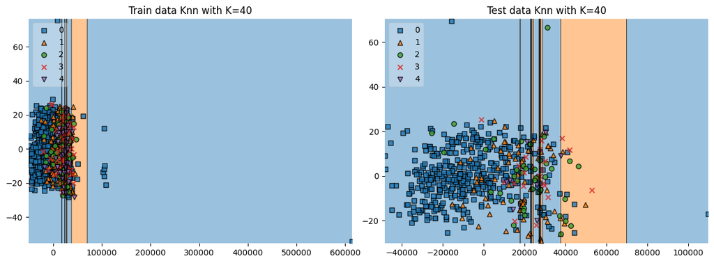

```python
fig, ax_lst = plt.subplots(1, 2,figsize=(15,11))
fig.subplots_adjust(hspace=0.2, wspace=0.1)

for (i,k) in [(1,1)]:
    sub1=plt.subplot(2,2,i)
    clf = KNeighborsClassifier(n_neighbors=40)
    clf.fit(X_train2, y_train)                        ################### fit
    plot_decision_regions(np.array(X_train2), np.array(y_train), clf=clf, legend=2) ######### train data plot
    plt.title('Train data Knn with K={}'.format(40))
    sub1=plt.subplot(2,2,i+1)
    plot_decision_regions(np.array(X_test2), np.array(y_test), clf=clf, legend=2)  ########## test data plot, clf for background as before
    plt.title('Test data Knn with K={}'.format(40))
plt.show()
```

Overall, k-neighbors may be ill-suited for our purposes, but not entirely useless, seeing as we identified a fairly clear dividing line of fish fans and haters.

```
Test accurancy: 0.7357142857142858
CV accurancy: 0.751, (0.731,0.772)
```

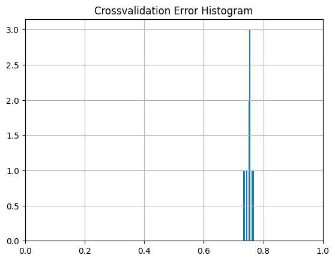

```python
print('Test accurancy: {}'.format(clf.score(X_test2,y_test)))
cv_score=cross_val_score(clf,X_train2 , y_train, cv=10)
plt.hist(cv_score)
plt.title('Crossvalidation Error Histogram')
plt.xlim(0,1)
plt.grid()
cv=np.mean(cv_score)
std=np.std(cv_score)
print('CV accurancy: {:3.3f}, ({:3.3f},{:3.3f})'.format(cv,cv-2*std,cv+2*std))
```

```python
X_train, X_test, y_train, y_test = train_test_split(train_data, categorized_wine)
```

```python
pca = PCA(n_components = 2)
X_train2 = pca.fit_transform(X_train)

X_test2 = pca.fit_transform(X_test)
```

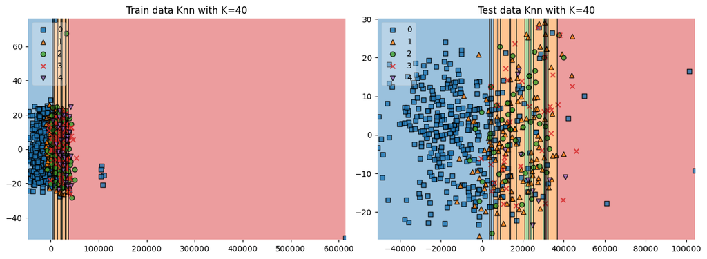

```python
fig, ax_lst = plt.subplots(1, 2,figsize=(15,11))
fig.subplots_adjust(hspace=0.2, wspace=0.1)

for (i,k) in [(1,1)]:
    sub1=plt.subplot(2,2,i)
    clf = KNeighborsClassifier(n_neighbors=40)
    clf.fit(X_train2, y_train)                        ################### fit
    plot_decision_regions(np.array(X_train2), np.array(y_train), clf=clf, legend=2) ######### train data plot
    plt.title('Train data Knn with K={}'.format(40))
    sub1=plt.subplot(2,2,i+1)
    plot_decision_regions(np.array(X_test2), np.array(y_test), clf=clf, legend=2)  ########## test data plot, clf for background as before
    plt.title('Test data Knn with K={}'.format(40))
plt.show()
```

```
Test accurancy: 0.6625
CV accurancy: 0.658, (0.617,0.698)
```

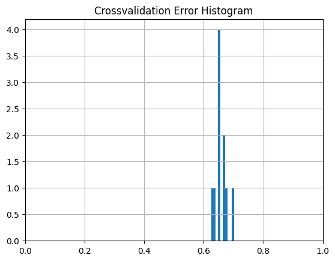

```python
print('Test accurancy: {}'.format(clf.score(X_test2,y_test)))
cv_score=cross_val_score(clf,X_train2 , y_train, cv=10)
plt.hist(cv_score)
plt.title('Crossvalidation Error Histogram')
plt.xlim(0,1)
plt.grid()
cv=np.mean(cv_score)
std=np.std(cv_score)
print('CV accurancy: {:3.3f}, ({:3.3f},{:3.3f})'.format(cv,cv-2*std,cv+2*std))
```

Seeing as low amounts of neighbors are pretty much useless for prediction and fitting a model for 30+ neighbors already takes a substantial amount of time, we shall skip grid-searching for the best parameters.

```python
bagging = BaggingClassifier(KNeighborsClassifier(),
                             max_samples=0.5, max_features=0.5)
bagging.fit(np.array(X_train2),np.array(y_train))
```

```
BaggingClassifier(estimator=KNeighborsClassifier(), max_features=0.5,
                  max_samples=0.5)
```

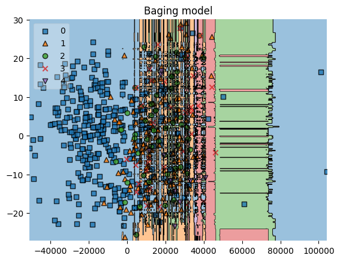

```python
plot_decision_regions(np.array(X_test2), np.array(y_test), clf=bagging, legend=2)
plt.title('Baging model')
```

And let us never speak of this graph again.

```python
bagging = BaggingClassifier(KNeighborsClassifier(),
                             max_samples=0.5, max_features=0.5)
bagging.fit(np.array(X_train),np.array(y_train))
```

```
BaggingClassifier(estimator=KNeighborsClassifier(), max_features=0.5,
                  max_samples=0.5)
```

```python
def confusion_matrix(y_model,y_test):
    disp=pd.DataFrame({'pred':y_model,'real':y_test}).groupby(['pred','real'])['pred'].count().unstack()
    disp.fillna(0,inplace=True)
    display(HTML('<H3>Confusion matrix</h3> '+disp._repr_html_()))
    return disp
```

```python
y_predict=bagging.predict(X_test)
conf=confusion_matrix(y_predict,y_test)
```

Confusion matrix

| real pred | 0 | 1 | 2 | 3 | 4 |
| --- | --- | --- | --- | --- | --- |
| 0 | 335.0 | 99.0 | 41.0 | 23.0 | 8.0 |
| 1 | 9.0 | 21.0 | 8.0 | 9.0 | 2.0 |
| 2 | 0.0 | 0.0 | 2.0 | 0.0 | 0.0 |
| 3 | 0.0 | 0.0 | 1.0 | 2.0 | 0.0 |

```python
print(bagging.score(X_test,y_test))
```

```
0.6428571428571429
```

Now for actually predicting the exact amounts of purchased products, rather than ranges.

```python
def get_preprocessor(ff_set):
    f_set=set(ff_set)

    standard_features = list(set(['Income', 'Year_Birth'])&f_set)
    standard_transformer = Pipeline(steps=[
        ('imputer', SimpleImputer(strategy='median')),
        ('scaler', StandardScaler())])

    categorical_features = list(set(['Marital_Status', 'Education', 'Kidhome', 'Teenhome'])&f_set)
    categorical_transformer = Pipeline(steps=[
#    ('imputer', SimpleImputer(strategy='constant', fill_value='missing')),
        ('onehot', OneHotEncoder(drop='first'))])#,handle_unknown='ignore'

    preprocessor = ColumnTransformer(
        transformers=[
            ('stand', standard_transformer, standard_features),
            ('cat', categorical_transformer, categorical_features)
                     ]
#    ,        remainder='passthrough'
            )
    return(preprocessor)
```

```python
train_data = campaign[['Income', 'Marital_Status', 'Education', 'Kidhome', 'Teenhome', 'Year_Birth']]
```

```python
X_train0, X_test0, y_train, y_test = train_test_split(train_data, fish_targets, test_size=0.1, random_state=0)

preprocessor=get_preprocessor(train_data.columns)
X_train=preprocessor.fit_transform(X_train0)
X_test=preprocessor.transform(X_test0)
```

```python
display(HTML(preprocessor._repr_html_()))
```

```
ColumnTransformer(transformers=[('stand',
                                 Pipeline(steps=[('imputer',
                                                  SimpleImputer(strategy='median')),
                                                 ('scaler', StandardScaler())]),
                                 ['Year_Birth', 'Income']),
                                ('cat',
                                 Pipeline(steps=[('onehot',
                                                  OneHotEncoder(drop='first'))]),
                                 ['Marital_Status', 'Education', 'Teenhome',
                                  'Kidhome'])])
```

```python
clf = LinearRegression().fit(X_train, y_train)
y_model=clf.predict(X_test)
display(HTML(clf._repr_html_()))
print(clf.score(X_test, y_test))
```

```
LinearRegression()
```

```
0.38278040135667224
```

In other words, Linear regression doesn't seem very well-suited to our task.

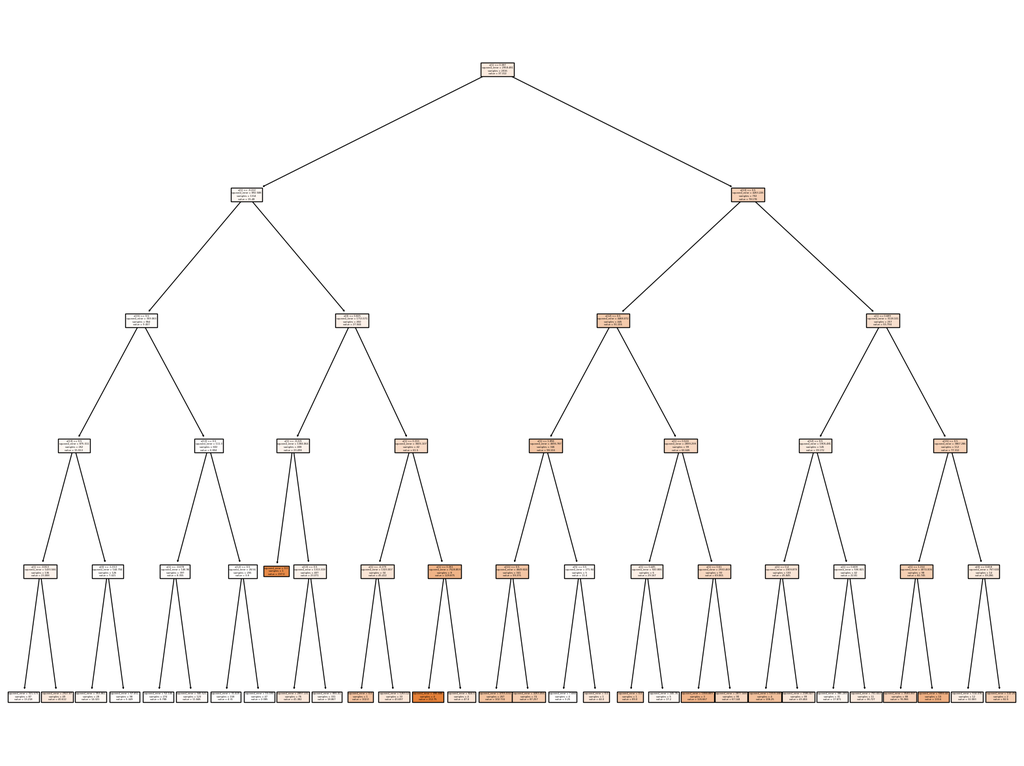

```python
tree_clf=DecisionTreeRegressor(max_depth=5)
tree_clf.fit(X_train, y_train)
fig, ax_lst = plt.subplots(1, 1,figsize=(20,15))
sklearn.tree.plot_tree(tree_clf,
                   filled=True)
plt.show()
```

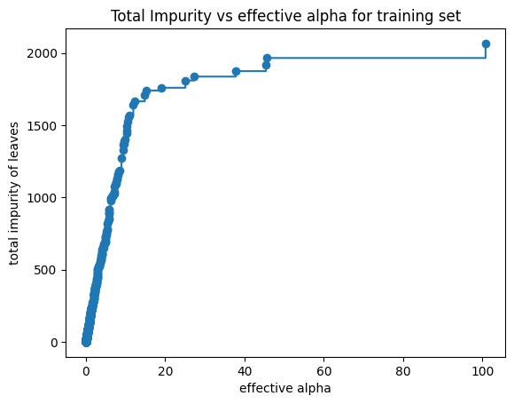

```python
tree_clf=DecisionTreeRegressor()
path = tree_clf.cost_complexity_pruning_path(X_train, y_train)
ccp_alphas, impurities = path.ccp_alphas, path.impurities
fig, ax = plt.subplots()
ax.plot(ccp_alphas[:-1], impurities[:-1], marker='o', drawstyle="steps-post")
ax.set_xlabel("effective alpha")
ax.set_ylabel("total impurity of leaves")
ax.set_title("Total Impurity vs effective alpha for training set")
```

```python
n_trees=8
ccp_alphas[(-n_trees):]
```

```
array([ 18.91820499,  25.08618916,  27.27907419,  37.78430325,
        45.3980451 ,  45.59589181, 100.76420445, 892.18868913])
```

```python
clfs = []
for ccp_alpha in ccp_alphas[(-n_trees):]:
    clf = DecisionTreeRegressor(ccp_alpha=ccp_alpha)
    clf.fit(X_train, y_train)
    clfs.append(clf)
print("Number of nodes in the last tree is: {} with ccp_alpha: {}".format(clfs[-1].tree_.node_count, ccp_alphas[-1]))
```

```
Number of nodes in the last tree is: 1 with ccp_alpha: 892.1886891341387
```

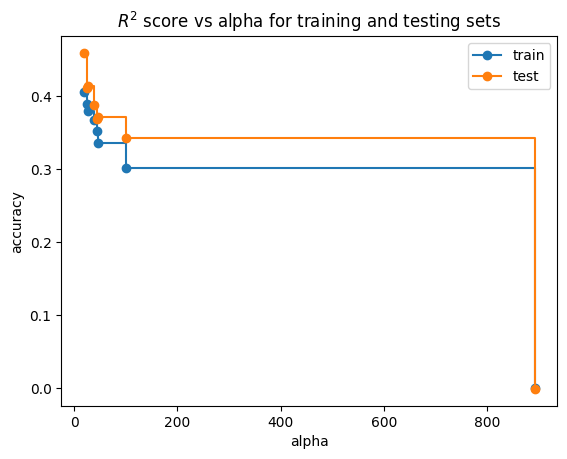

```python
train_scores = [clf.score(X_train, y_train) for clf in clfs]
test_scores = [clf.score(X_test, y_test) for clf in clfs]

fig, ax = plt.subplots()
ax.set_xlabel("alpha")
ax.set_ylabel("accuracy")
ax.set_title("$R^2$ score vs alpha for training and testing sets")
ax.plot(ccp_alphas[(-n_trees):], train_scores, marker='o', label="train",
        drawstyle="steps-post")
ax.plot(ccp_alphas[(-n_trees):], test_scores, marker='o', label="test",
        drawstyle="steps-post")
ax.legend()
plt.show()
```

Now back to classification

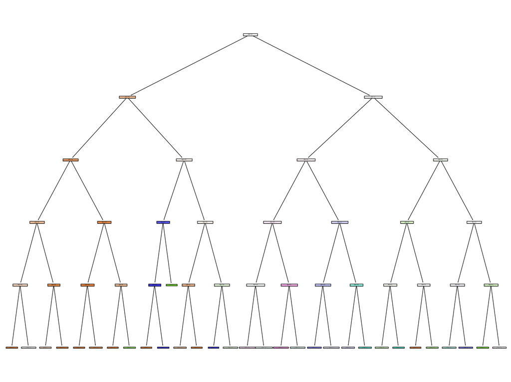

```python
tree_clf=DecisionTreeClassifier(class_weight='balanced',max_depth=5)

X_train, X_test, y_train, y_test = train_test_split(train_data, categorized_fish)
preprocessor=get_preprocessor(train_data.columns)
X_train=preprocessor.fit_transform(X_train)
X_test=preprocessor.transform(X_test)
tree_clf.fit(X_train, y_train)

fig, ax_lst = plt.subplots(1, 1,figsize=(20,15))
sklearn.tree.plot_tree(tree_clf,
                   filled=True)
plt.show()
```

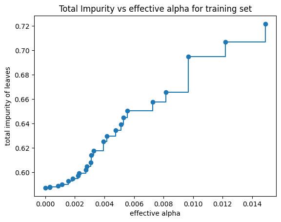

```python
path = tree_clf.cost_complexity_pruning_path(X_train, y_train)
ccp_alphas, impurities = path.ccp_alphas, path.impurities
fig, ax = plt.subplots()
ax.plot(ccp_alphas[:-1], impurities[:-1], marker='o', drawstyle="steps-post")
ax.set_xlabel("effective alpha")
ax.set_ylabel("total impurity of leaves")
ax.set_title("Total Impurity vs effective alpha for training set")
```

```python
clfs = []
for ccp_alpha in ccp_alphas[(-4):]:
    clf = DecisionTreeClassifier(random_state=0, ccp_alpha=ccp_alpha,class_weight='balanced')
    clf.fit(X_train, y_train)
    clfs.append(clf)
print("Number of nodes in the last tree is: {} with ccp_alpha: {}".format(
      clfs[-1].tree_.node_count, ccp_alphas[-1]))
```

```
Number of nodes in the last tree is: 3 with ccp_alpha: 0.07817505909025135
```

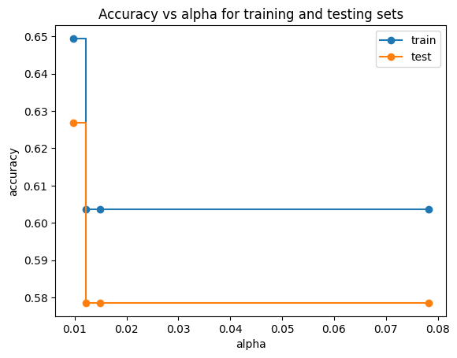

```python
train_scores = [clf.score(X_train, y_train) for clf in clfs]
test_scores = [clf.score(X_test, y_test) for clf in clfs]

fig, ax = plt.subplots()
ax.set_xlabel("alpha")
ax.set_ylabel("accuracy")
ax.set_title("Accuracy vs alpha for training and testing sets")
ax.plot(ccp_alphas[(-4):], train_scores, marker='o', label="train",
        drawstyle="steps-post")
ax.plot(ccp_alphas[(-4):], test_scores, marker='o', label="test",
        drawstyle="steps-post")
ax.legend()
plt.show()
```

**Author:** *Martin Gráf*